# Homework 4: SCC and Climate Policy

Iris Foxfoot

5/19/2021

1. Using damages.csv, estimate a quadratic damage function relating the dollar value of damages to the change in global mean temperature. Omit an intercept term; damages by construction must equal zero when there is no climate change. Plot your estimated damage function, overlaid with a scatterplot of the underlying data.

```r
#read in data
damages_data <- read_csv(here("damages.csv"))

warming_data <- read_csv(here("warming.csv"))

#creating vectors of values
damages_data <- damages_data %>%
  mutate(warming2 = warming^2)

#creating vectors
damages <- damages_data$damages
warming <- damages_data$warming
warming2 <- damages_data$warming2

#estimating quadratic model
damages_quad_model=lm(method = 'lm', damages ~ warming + warming2)

summary(damages_quad_model)
```

```
##
## Call:
## lm(formula = damages ~ warming + warming2, method = "lm")
##
## Residuals:
##              Min               1Q           Median               3Q
## -140964558638458  -16197874023958    -418039020615   16983759667207
##              Max
##  142165441361542
##
## Coefficients:
##                   Estimate     Std. Error t value            Pr(>|t|)
## (Intercept)  4198128185511  4967607804306   0.845               0.398
## warming     -3018856250104  2537526504744  -1.190               0.235
## warming2    19589020155100   270647967590  72.378 <0.0000000000000002 ***
## ---
## Signif. codes:  0 '***' 0.001 '**' 0.01 '*' 0.05 '.' 0.1 ' ' 1
##
## Residual standard error: 34670000000000 on 553 degrees of freedom
## Multiple R-squared:  0.9902, Adjusted R-squared:  0.9901
## F-statistic: 2.784e+04 on 2 and 553 DF,  p-value: < 0.00000000000000022
```

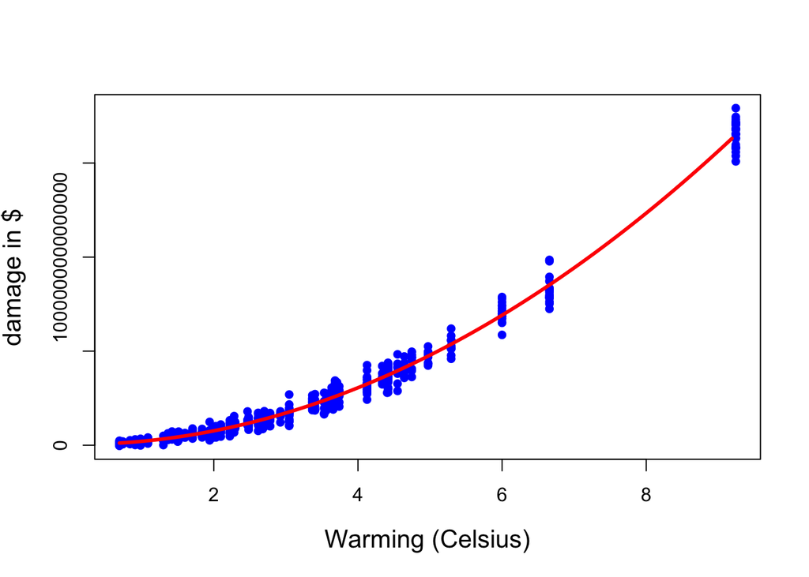

```r
#creating a sequence of warming values to test predictions on
warmingvalues <- seq(0.6900000, 9.243000, 0.1)

#generating predictions
predictedcounts <- predict(damages_quad_model,list(warming=warmingvalues, warming2=warmingvalues^2))

#plotting
plot(warming, damages, pch=16, xlab = "Warming (Celsius)", ylab = "damage in $", cex.lab = 1.3, col = "blue");
lines(warmingvalues, predictedcounts, col = "red", lwd = 3)
```

2. Use warming.csv and your estimated damage function to predict damages in each year under the baseline climate and the pulse scenario. Make four plots: (1) damages over time without the pulse, (2) damages over time with the pulse, (3) the difference in damages over time that arises from the pulse, and (4) the difference in damages over time from the pulse per ton of CO2 (you can assume that each ton of the pulse causes the same amount of damage).

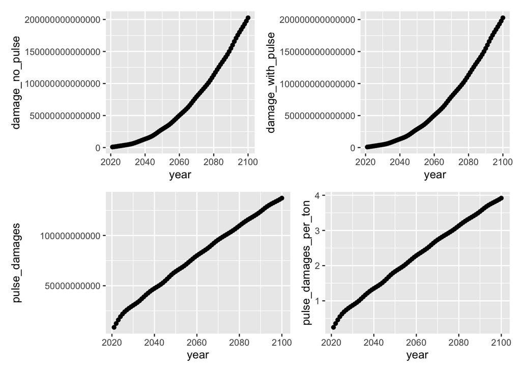

```r
#making a damage function--do it with stored intercepts later
damage_function <- function(x){
  damage <- -3018856250104*x + 19589020155100*x^2
  return(damage)
}

#creating new columns
warming_scenarios <- warming_data %>%
  mutate(damage_no_pulse = damage_function(warming_baseline)) %>%
  mutate(damage_with_pulse = damage_function(warming_pulse)) %>%
  mutate(pulse_damages = damage_with_pulse - damage_no_pulse) %>%
  mutate(pulse_damages_per_ton = pulse_damages/35000000000)

#create graphs
damage_no_pulse_graph <- ggplot(data = warming_scenarios, aes(x = year, y = damage_no_pulse)) +
  geom_point()

damage_with_pulse_graph <- ggplot(data = warming_scenarios, aes(x = year, y = damage_with_pulse)) +
  geom_point()

pulse_damages_graph <- ggplot(data = warming_scenarios, aes(x = year, y = pulse_damages)) +
  geom_point()

pulse_damages_per_ton_graph <- ggplot(data = warming_scenarios, aes(x = year, y = pulse_damages_per_ton)) +
  geom_point()

#put the graphs together
(damage_no_pulse_graph + damage_with_pulse_graph)/(pulse_damages_graph + pulse_damages_per_ton_graph)
```

3. The SCC is the present discounted value of the stream of future damages caused by one additional ton of CO2. The Obama Administration used a discount rate of 3% to discount damages. Recently, New York State used a discount rate of 2%. Calculate and make a plot of the SCC (y-axis) against the discount rate (x-axis) for a reasonable range of discount rates.

```r
#function that takes in two vectors. first co2 damage per ton, then discount rate
scc_function <- function(num, dr = .02) {
  sum <- 0;
  r <- dr
  for(t in c(1:length(num))){
      present <- num[t]/(1+r)^t
      sum <- sum+present
  }
  return(sum)
}

#generating a list of discount rates to use
discount_rate <- seq(.01, .1, .001)

#testing it out
scc_function(warming_scenarios$pulse_damages_per_ton, discount_rate)
```

```
##  [1] 110.623796 105.634767 100.919352  96.460960  92.244074  88.254175
##  [7]  84.477679  80.901868  77.514839  74.305444  71.263243  68.378453
## [13]  65.641909  63.045018  60.579727  58.238481  56.014197  53.900227
## [19]  51.890334  49.978661  48.159713  46.428325  44.779648  43.209126
## [25]  41.712474  40.285668  38.924920  37.626670  36.387567  35.204459
## [31]  34.074377  32.994527  31.962277  30.975148  30.030804  29.127041
## [37]  28.261785  27.433076  26.639067  25.878016  25.148278  24.448298
## [43]  23.776610  23.131829  22.512645  21.917820  21.346185  20.796632
## [49]  20.268116  19.759645  19.270281  18.799138  18.345375  17.908195
## [55]  17.486843  17.080604  16.688800  16.310787  15.945955  15.593725
## [61]  15.253548  14.924900  14.607287  14.300236  14.003301  13.716056
## [67]  13.438096  13.169035  12.908508  12.656166  12.411677  12.174724
## [73]  11.945008  11.722240  11.506147  11.296469  11.092956  10.895372
## [79]  10.703490  10.517094  10.335978  10.159944   9.988804   9.822379
## [85]   9.660496   9.502990   9.349706   9.200491   9.055202   8.913701
## [91]   8.775856
```

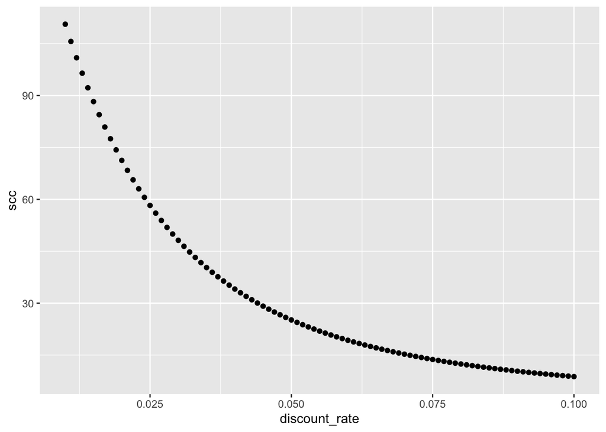

```r
#creating a dataframe
scc <- data.frame(discount_rate<-discount_rate,
scc<-scc_function(warming_scenarios$pulse_damages_per_ton, discount_rate))
colnames(scc) = c("discount_rate", "scc")

#graphing
ggplot(data = scc, aes(x = discount_rate, y = scc)) +
  geom_point()
```

4. The National Academies of Sciences, Engineering, and Medicine advised the government in a 2017 report to use the Ramsey Rule when discounting within the SCC calculation:

r = ρ + ηg

Using ρ = 0.001, η = 2, and g = 0.01, what is the SCC? Locate this point on your graph from above.

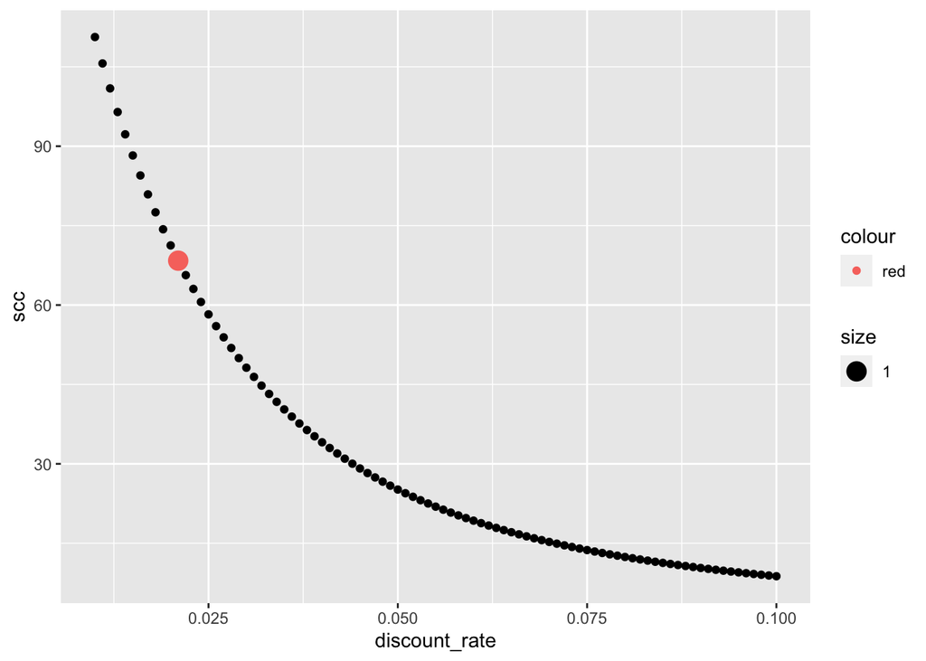

```r
#finding discount rate
ramsey_discount_rate <- 0.001 + 2*0.01

#inserting this into discount rate
ramsey_point <- data.frame(ramsey_discount_rate, scc_function(warming_scenarios$pulse_damages_per_ton, ramsey_discount_rate))

#changing col names
colnames(ramsey_point) = c("discount_rate", "ramsey_scc")

ggplot() +
  geom_point(data = scc, aes(x = discount_rate, y = scc)) +
  geom_point(data = ramsey_point, aes(x = ramsey_discount_rate, y = ramsey_scc, color = "red", size = 1))#
```

5. Now suppose there are two possible climate policies that can be pursued. Policy A is business as usual and Policy B is to take immediate and strong action on climate change. Use these facts

• If you undertake Policy A there are two possible outcomes. Either warming will occur as in the “baseline” (i.e. “no-pulse”) dataset above (this happens with probability 0.5) or warming each year will be 1.5 times that in the “baseline” dataset (with probability 0.5).

• Under Policy B, warming will continue until 2050 as in the “baseline” dataset, and then will stabilize at 1.29 degrees and stay that way forever.

• Society is risk neutral

• Use a discount rate of 2% What is the expected present value of damages up to 2100 under Policy A? What is the expected present value of damages up to 2100 under Policy B? Suppose undertaking Policy A costs zero and undertaking Policy B costs X. How large could X be for it to still make economic sense to pursue Policy B instead of Policy A? Qualitatively, how would your answer change if society were risk averse?